[OHI British Columbia](http://www.ohibc.org/) | [OHI Science](http://ohi-science.org) | [Citation policy](https://github.com/OHI-Science/ohiprep/releases)

# OHIBC: Ocean Acidification Pressure layers prep

Compiled on Wed Mar 16 12:44:01 2016 by ohara

# 1 Summary

There are two parts to creating this layer:

1. Data prep to get raw data into the correct format:
   - Aggregate monthly values for aragonite saturation state to an annual mean value per cell, for baseline decade and current study period.
   - Clip rasters to extents of OHIBC region, and reproject into BC Albers projection.
   - Determine baseline by calculating decadal mean for 1880-1889.
2. Creating the pressure layers for OHIBC:
   - Determine change in aragonite saturation state since baseline for each year of study period (2005-2014)
   - Rescale to values from 0 - 1.
   - Interpolate to coastline at 1 km resolution.

This process is completed entirely within this script.

# 2 Updates

Not applicable.

# 3 Data

Raw data was provided by Woods Hole on December 16, 2014. This data is an update to the work done by Feely et al. (2009).

Native Data Resolution: 1 degree Values: Surface Ω aragonite saturation state Time Range: 1880-1889 and 2005-2014 (monthly data was provided for each year) Format: NetCDF

# 4 Methods

## 4.1 Data Prep

### 4.1.1 Read raw data

Raw data is read in for 1880 - 1889 and 2005 - 2014 datasets. Latitude, longitude, and aragonite saturation state $\Omega$ are extracted for each year in each dataset. Land cells are set to NA.

Range of $\Omega_{1880-1889}$ for global dataset: 0.073 - 4.961.

Range of $\Omega_{2005-2014}$ for global dataset: 0.071 - 4.451.

### 4.1.2 Convert raw global data to OHIBC region data

The raw data, in WGS84 coordinate ref system, is rasterized, clipped down to a bounding box around the OHIBC region, and reprojected into BC Albers projection. This data is then resampled to 1 km resolution using nearest neighbor method.

The resulting raster layers (in rasterBrick format) include annual means for each coarse cell (approx 1 degree, from original resolution) for each year in the dataset. The two decades (1880-1889 and 2005-2014) are assigned to two separate rasterBricks.

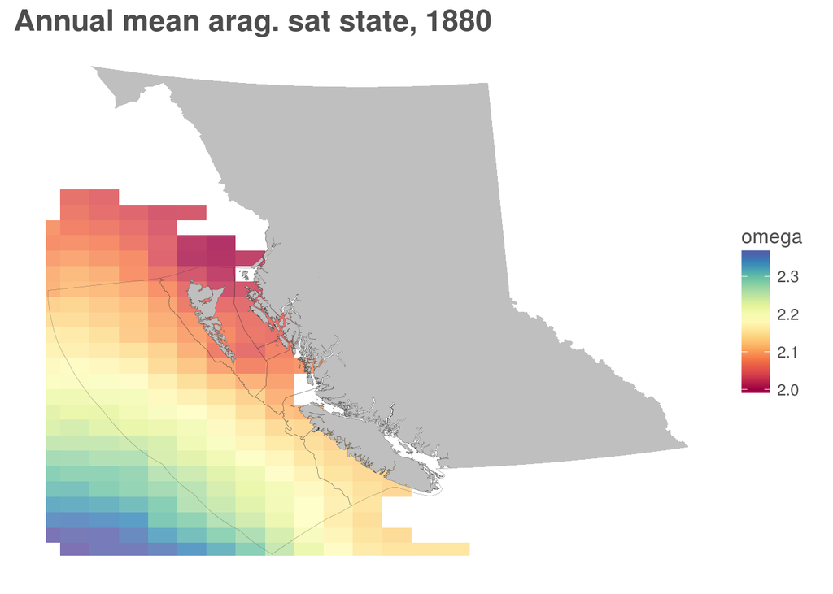

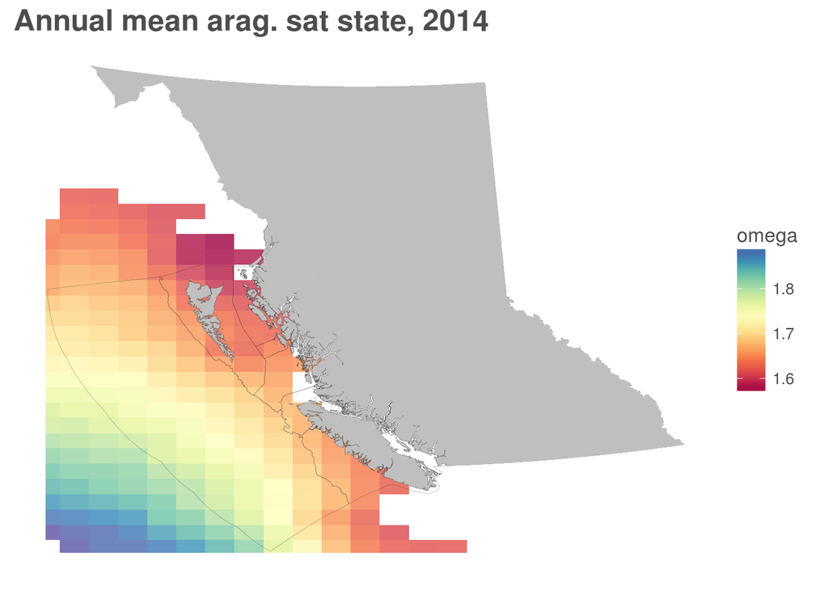

### 4.1.3 Calculate baseline

Determine the mean cell value across the entire decade from 1880-1889, as a baseline for ocean aragonite saturation levels.

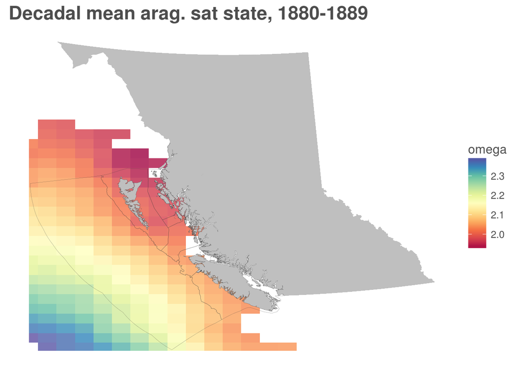

## 4.2 Rescale values as pressures

Baseline aragonite saturation state $\Omega_{base}$ is based upon the decadal average from 1880-1889.

Deviation from aragonite saturation state is determined for each year in the study period:

$\Delta \Omega_{year} = \frac{(\Omega_{base} - \Omega_{year})}{(\Omega_{base} - 1)}$

$\Delta \Omega_{year}$ is then modified to account for increases in aragonite saturation state (pressure = 0) and arag sat state less than 1 (pressure = 1).

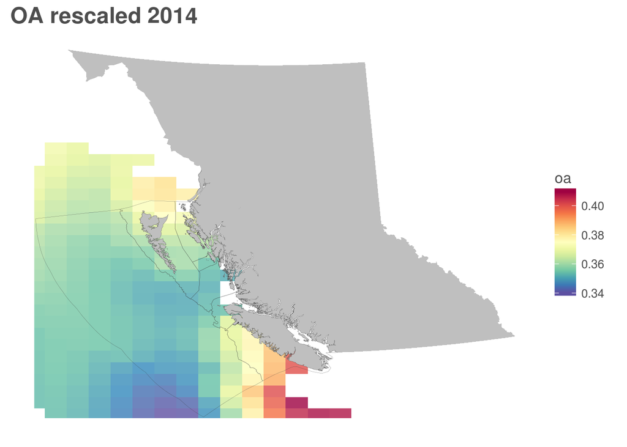

### 4.2.1 Interpolate layer to coastline at 1 km

Now that $\Delta \Omega_{year}$ has been determined at a 1 degree cell scale, we interpolate that to the coastlines to fill NAs. Using `raster::interpolate()`, we select a random sample of points from the $\Delta \Omega_{year}$ raster (for speed and memory) and apply the thin plate spline model (`fields::Tps()`).

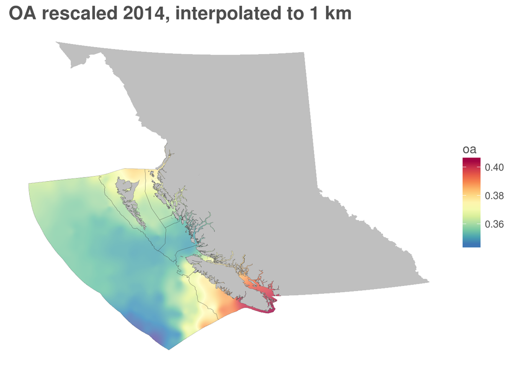

## 4.3 Calculate mean pressure by region by year

Using 1000 m region ID raster to run zonal statistics on the pressures layers (within brick or separately?) we can calculate the regional average pressures for each year of study, and save as a .csv.

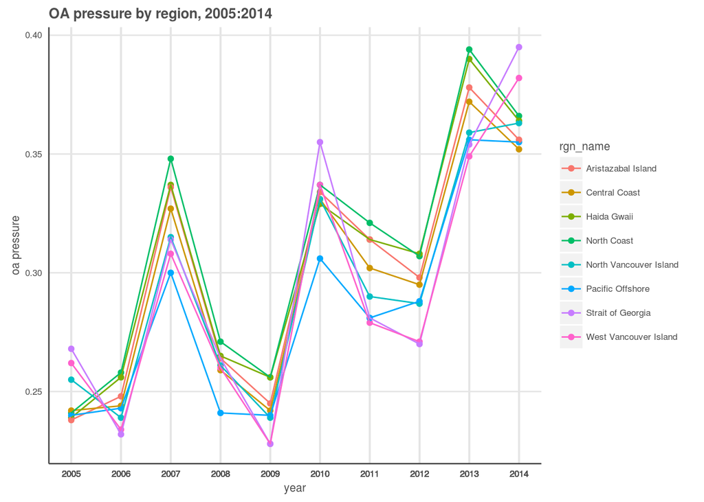

## 4.4 Smooth annual pressures with running average

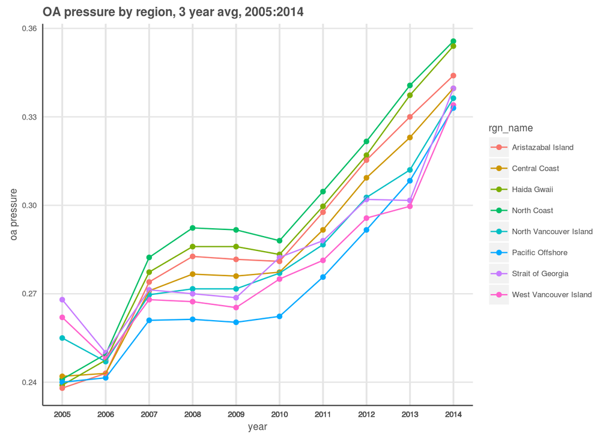

# 5 Provenance

- *Run ID: 1; run tag: “standard run”*
- *Run elapsed time: 232.235 seconds; run memory usage: NA MB*
- *System info: System: Linux, Release: 3.2.0-99-generic. Machine: x86_64. User: ohara.*
- *Session info*
  - *R version: R version 3.2.3 (2015-12-10), Platform: x86_64-pc-linux-gnu, Running under: Ubuntu precise (12.04.5 LTS).*
  - *Attached base packages: stats, graphics, grDevices, utils, datasets, methods, base*
  - *Other attached packages: maptools_0.8-39, RColorBrewer_1.1-2, ncdf4_1.15, ggplot2_2.0.0, readr_0.2.2, stringr_1.0.0, tidyr_0.4.1, dplyr_0.4.3, raster_2.5-2, rgdal_1.1-3, sp_1.2-2*

Provenance summary for this run:

| run_id | run_tag | run_date | file_loc | type | commit_url | commit_author | commit_date | uncommitted_changes |
| --- | --- | --- | --- | --- | --- | --- | --- | --- |
| 1 | standard run | Wed Mar 16 12:47:55 2016 | ~/github/ohibc/prep/pressures/v2016/pressures_lyr_fxns.R | sourced_script | https://github.com/OHI-Science/ohibc/commit/5f6534a816eedf6fbe016bfeb156a5d4295fff85 | Casey O’Hara ohara@nceas.ucsb.edu | Tue Mar 15 11:09:01 2016 -0700 | FALSE |
| 1 | standard run | Wed Mar 16 12:47:55 2016 | ~/github/ohibc/src/R/rast_tools.R | sourced_script | https://github.com/OHI-Science/ohibc/commit/c4744464da326817b3f3c0f5634f5bfbd2f59e12 | Casey O’Hara ohara@nceas.ucsb.edu | Tue Mar 15 15:05:57 2016 -0700 | TRUE |
| 1 | standard run | Wed Mar 16 12:47:55 2016 | /var/data/ohi/git-annex/globalprep/Pressures_OceanAcidification/v2015/input/cesm_co2sys_1880-1889.nc | input | no version control info found | NA | NA | TRUE |
| 1 | standard run | Wed Mar 16 12:47:55 2016 | /var/data/ohi/git-annex/globalprep/Pressures_OceanAcidification/v2015/input/cesm_co2sys_2005-2014.nc | input | no version control info found | NA | NA | TRUE |
| 1 | standard run | Wed Mar 16 12:47:55 2016 | /home/ohara/github/ohibc/prep/regions/ohibc_rgn.shp | input | https://github.com/OHI-Science/ohibc/commit/b4848d164d7ab5393da401425b57d0a540866c1f | Casey O’Hara ohara@nceas.ucsb.edu | Wed Oct 28 15:07:36 2015 -0700 | FALSE |
| 1 | standard run | Wed Mar 16 12:47:55 2016 | /home/ohara/github/ohibc/prep/regions/ohibc_rgn_wgs84.shp | input | https://github.com/OHI-Science/ohibc/commit/b014927db4445d63bc01ddf683252c301cd59d0f | Casey O’Hara ohara@nceas.ucsb.edu | Wed Oct 28 11:55:33 2015 -0700 | FALSE |
| 1 | standard run | Wed Mar 16 12:47:55 2016 | ~/github/ohibc/prep/regions/ohibc_rgn_raster_1000m.tif | input | https://github.com/OHI-Science/ohibc/commit/c4744464da326817b3f3c0f5634f5bfbd2f59e12 | Casey O’Hara ohara@nceas.ucsb.edu | Tue Mar 15 15:05:57 2016 -0700 | FALSE |
| 1 | standard run | Wed Mar 16 12:47:55 2016 | ~/github/ohibc/prep/pressures/v2016/int/oa/rbrick_a18_1km_raw.tif | input | https://github.com/OHI-Science/ohibc/commit/10da874232ed737bb51f17e2afea88653b0f334a | Casey O’Hara ohara@nceas.ucsb.edu | Mon Mar 14 18:17:16 2016 -0700 | FALSE |
| 1 | standard run | Wed Mar 16 12:47:55 2016 | ~/github/ohibc/prep/pressures/v2016/int/oa/rbrick_a20_1km_raw.tif | input | https://github.com/OHI-Science/ohibc/commit/10da874232ed737bb51f17e2afea88653b0f334a | Casey O’Hara ohara@nceas.ucsb.edu | Mon Mar 14 18:17:16 2016 -0700 | FALSE |
| 1 | standard run | Wed Mar 16 12:47:55 2016 | ~/github/ohibc/prep/pressures/v2016/output/oa/oa_rescaled_2005-2014_2000pts.tif | input | no version control info found | NA | NA | TRUE |
| 1 | standard run | Wed Mar 16 12:47:55 2016 | ~/github/ohibc/prep/pressures/v2016/output/oa/oa_rgn_pressures.csv | output | New commit: https://github.com/OHI-Science/ohibc/commit/b687ba732738fbe7569c14e20fa0ddcb9eb743e4 | Casey O’Hara ohara@nceas.ucsb.edu | Wed Mar 16 12:47:53 2016 -0700 | FALSE |
| 1 | standard run | Wed Mar 16 12:47:55 2016 | ~/github/ohibc/prep/pressures/v2016/pressures_oa_prep.Rmd | script | https://github.com/OHI-Science/ohibc/commit/3aa6ef933fdb2e15aa4e101034cf2d1524b23e5a | Casey O’Hara ohara@nceas.ucsb.edu | Wed Mar 16 10:49:03 2016 -0700 | TRUE |